# Value at Risk avec l’action ORPEA

Alex FABRE

24 décembre, 2020

```r
library(QuantTools)
library(xts)
library(forecast)
library(moments)
library(BatchGetSymbols)
library(knitr)
library(rugarch)
library(ghyp)
library(SkewHyperbolic)
library(PerformanceAnalytics)
library(parallel)
library(zoo)
library(ggplot2)
```

# 1 Axe principal d’étude

Ce projet suit un premier où l’on avait couplé un modèle ARMA(4,4) sans AR2 et MA2 avec un GARCH(1,1). Nous avions établi une faiblesse quand à la prise en compte d’effet de levier dans les rendements de l’action Orpea. Il s’agira ici de mettre en lumière cet effet au travers d’un modèle GARCH plus élaboré. Des raccourcis ou des idées que nous allons utiliser dans ce travail pourront faire référence à ce premier projet. Vous pourrez vous y référer [ici](https://drive.google.com/file/d/1Txs-Dh8fAsC_Od53aQfzJsO2WFI8EpxH/view?usp=sharing). Nous apprécierons pour finir le backtesting du modèle retenu et le calcul de la Value at Risk.

## 1.1 Visualisation de l’asymétrie

```r
first.date <- "2009-12-31"
last.date <- "2019-12-31"
freq.data <- 'daily'
type.return <- 'log'
tickers <- 'ORP.PA'
tab <- BatchGetSymbols(tickers = tickers,
                       first.date = first.date,
                       last.date = last.date,
                       freq.data = freq.data,
                       type.return=type.return,
                       cache.folder = file.path(tempdir(),
                                                'BGS_Cache') )
kable(head(tab$df.tickers), caption="Les 6 premières lignes de données")
```

Table 1.1: Les 6 premières lignes de données

| price.open | price.high | price.low | price.close | volume | price.adjusted | ref.date | ticker | ret.adjusted.prices | ret.closing.prices |
| --- | --- | --- | --- | --- | --- | --- | --- | --- | --- |
| 29.4170 | 29.5571 | 29.3283 | 29.5384 | 20228 | 26.28418 | 2009-12-31 | ORP.PA | NA | NA |
| 29.5991 | 29.8839 | 29.5104 | 29.6785 | 54960 | 26.40884 | 2010-01-04 | ORP.PA | 0.0047317 | 0.0047317 |
| 29.5384 | 29.8746 | 29.2862 | 29.2862 | 124148 | 26.05976 | 2010-01-05 | ORP.PA | -0.0133065 | -0.0133064 |
| 29.2909 | 29.8839 | 29.2909 | 29.8186 | 73813 | 26.53350 | 2010-01-06 | ORP.PA | 0.0180159 | 0.0180159 |
| 29.8746 | 30.1501 | 29.6971 | 30.1314 | 74884 | 26.81184 | 2010-01-07 | ORP.PA | 0.0104354 | 0.0104354 |
| 30.1547 | 30.4536 | 29.8186 | 30.4349 | 84901 | 27.08191 | 2010-01-08 | ORP.PA | 0.0100224 | 0.0100222 |

```r
pt<-tab$df.tickers$price.adjusted
dates<-tab$df.tickers$ref.date[-1]
rendement=tab$df.tickers$ret.adjusted.prices[-1]
N<-length(rendement)
rt<-xts(x=rendement,order.by=dates)
rte=rendement[1:1534]
rtt=rendement[1535:N]
jour=format(dates, format = "%A")
mois=format(dates, format = "%B")
moisrte=mois[1:N]
mai=as.integer(moisrte=="mai")
jourrte=jour[1:N]
lundi=as.integer(jourrte=="lundi")
```

Dans un premier temps, il convient de s’intéresser à la leptokurticité remarquée lors du premier projet.

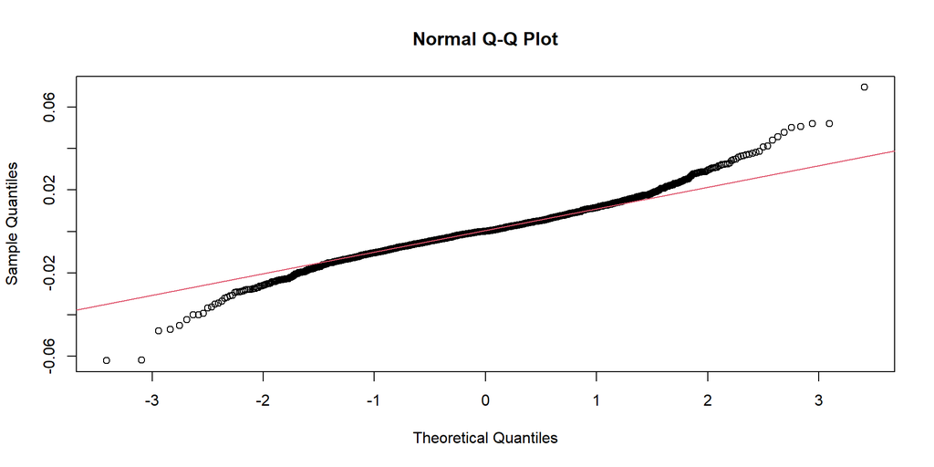

```r
qqnorm(rte)
qqline(rte,col=2)
```

Les queues de distribution sont effectivement plus épaisses qu’une loi normale. On constate qu’il y a une sur-représentation de rendements très faibles et très élevés. Il n’est pas aisé de distinguer lequel des deux effets est le plus représenté. Il nous faudra prendre en compte cette sur-représentation des extrêmes dans la modélisation.

```r
fitn <- fit.gaussuv(data = rte)
fitstu <- fit.tuv(rte,silent=T)
fitnig <- fit.NIGuv(data = rte,silent=T)
fithyp<- fit.hypuv(rte,silent=T)
fitghypuv <- fit.ghypuv(rte,silent=T)
```

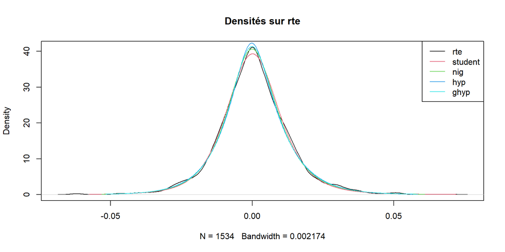

Figure 1.1: Densités selon les distributions

```r
plot(density(rte), main="")
lines(fitstu,col=2)
lines(fitnig,col=3)
lines(fithyp,col=4)
lines(fitghypuv,col=5)
title(main = "Densités sur rte")
legend("topright",legend =c("rte","student","nig","hyp","ghyp"), col =1:5,lty=rep(1,5))
```

La distribution de student asymétrique prend le plus en compte les valeurs extrêmes mais sous représente les valeurs proche de la moyenne. En revanche la distribution hyperbolique généralisée modélise pertinemment les valeurs moyennes mais est moins performante dans les extrêmes. Ces quatre distributions ne semblent pas adaptées pour nos données. On commencera par tester des modèles suivants d’autres distributions.

Nous pouvons tester la distribution généralisée hyperbolique asymétrique, cela compensera peut être le manque de prise en compte des valeurs extrêmes cité juste avant.

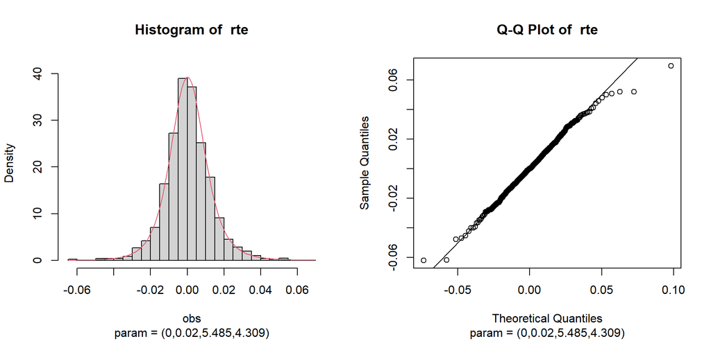

Figure 1.2: Distribution ghyp asymétrique sur rte

```r
ghstfit<-skewhypFit(rte, print = FALSE, plot =FALSE, hessian = TRUE)
op <- par(mfrow = c(1,2))
plot(ghstfit, which = 1)
plot(ghstfit, which = 3)
```

La prise en compte de la leptokurticité est nettement mieux réalisée. Le graphique en Q-Q plot reflète néanmoins une faiblesse pour les valeurs les plus extrêmes positives. Il pourra être intéressant d’utiliser cette distribution dans notre recherche de modèle.